# File S2

Jullien Flynn

2018-01-08

**This file details the analysis of paired-end reads to determine interspersion between repeats (when there are repeats on both mate pairs).**

Specifically, kseek was run separately for R1 and R2.

Next, Perl scripts were used:  
`pl rep_mate.pl read_1.rep`  
Followed by:  
`pl mp.compile.updated.pl read_1.rep.mp read_2.rep.mp outfile`

*Note*: one MA line per ancestor was randomly chosen to be representative, so 6 MA lines in total were used.

**Import required packages**

# Import and clean up data

```r
rm(list=ls())
CC_2931_MA1.rep <- read.delim("ERR968392.out.rep.mpx")
CC_2937_MA4.rep <- read.delim("ERR968409.out.rep.mpx")
CC_1952_MA2.rep <- read.delim("ERR968352.out.rep.mpx")
CC_2342_MA7.rep  <- read.delim("ERR968369.out.rep.mpx")
CC_2344_MA15.rep <- read.delim("ERR968391.out.rep.mpx")
CC_1373_MA7.rep <- read.delim("ERR968344.out.rep.mpx")

# import the names of the common kmers you are interested in.
# already have the common kmer union in my environment, but can import in file if not in environment
common.kmer.union <- read.table("../../chlamy_union_kmers.txt")
common.kmer.union <- as.vector(common.kmer.union$V1)

#head(CC_1373_MA7.rep)
#ncol(CC_1373_MA7.rep)

process_rep_files <- function(inputrep) {
  kmer_names <- inputrep[,1]
  inputrep$X <- NULL
  rownames(inputrep) <- kmer_names
  inputrep <- as.matrix(inputrep)
  return(inputrep)
}
CC_2931_MA1.rep <- process_rep_files(CC_2931_MA1.rep)
CC_2937_MA4.rep <- process_rep_files(CC_2937_MA4.rep)
CC_1952_MA2.rep <- process_rep_files(CC_1952_MA2.rep)
CC_2342_MA7.rep <- process_rep_files(CC_2342_MA7.rep)
CC_2344_MA15.rep <- process_rep_files(CC_2344_MA15.rep)
CC_1373_MA7.rep <- process_rep_files(CC_1373_MA7.rep)
```

Important analysis steps: 1) Take the mpx matrix (generated from the perl scrips) and look at the kmers of interest (the common union kmers)  
2) Make a pairwise matrix by adding the two triangles of the matrix, because identity of R1 vs R2 is not important here. 3) Calculate the interspersion metric, by bringing in data generated from external scripts. A metric is calculated for each pair of kmers i and j. Shell script `run_get_ni,nj.sh` is used to calculate values required for the interspersion metric. Python script `extract.py` is used to get the reads containing specific kmers.

```r
get_intsp_metric.mx <- function(totalreadsfile, inputrep) {
  interspersion.matrix <- matrix(ncol=ncol(inputrep), nrow=nrow(inputrep))
  interspersion.matrix <- inputrep[colnames(inputrep) %in% common.kmer.union, rownames(inputrep) %in% common.kmer.union]

  pairwise.matrix <- matrix(ncol=ncol(interspersion.matrix), nrow=nrow(interspersion.matrix))

  rownames(pairwise.matrix) <- rownames(interspersion.matrix)
  colnames(pairwise.matrix) <- colnames(interspersion.matrix)

  for (i in 1:nrow(interspersion.matrix)) {
    pairwise.matrix[i,i] <- interspersion.matrix[i,i]
    for (j in (i+1):nrow(interspersion.matrix)) {
      if (j <= nrow(interspersion.matrix)) {
        sum <- interspersion.matrix[i,j] + interspersion.matrix[j,i]
        pairwise.matrix[i,j] <- sum
      }
    }
  }

  total.reads <- read.table(totalreadsfile, quote="\"", comment.char="")
  read.counts <- as.vector(total.reads[,1])
  names(read.counts) <- common.kmer.union
  read.counts_temp <- read.counts[names(read.counts) %in% colnames(pairwise.matrix)]
  read.counts <- read.counts_temp[order(match(names(read.counts_temp), colnames(pairwise.matrix)))]
  names(read.counts) == colnames(pairwise.matrix)

  interspersion.metric.matrix <- matrix(ncol=ncol(pairwise.matrix), nrow=nrow(pairwise.matrix))
  rownames(interspersion.metric.matrix) <- rownames(pairwise.matrix)
  colnames(interspersion.metric.matrix) <- colnames(pairwise.matrix)

  for (i in 1:ncol(pairwise.matrix)) {
    for (j in i:ncol(pairwise.matrix)) { # i will equal j, for the same kmer with itself
      ni <- as.numeric(read.counts[i])
      nj <- as.numeric(read.counts[j])
      nij <- pairwise.matrix[i,j]
      interspersion.metric.matrix[i,j] <- nij / (sqrt(ni*nj))
    }
  }
return(interspersion.metric.matrix)
}
```

Using this function, generate interspersion metric matrices for all of the ancestors.

```r
interspersion.metric.matrix_1373 <- get_intsp_metric.mx("ERR968344.total.reads.txt", CC_1373_MA7.rep)
interspersion.metric.matrix_1952 <- get_intsp_metric.mx("ERR968352.total.reads.txt", CC_1952_MA2.rep)
interspersion.metric.matrix_2342 <- get_intsp_metric.mx("ERR968369.total.reads.txt", CC_2342_MA7.rep)
interspersion.metric.matrix_2344 <- get_intsp_metric.mx("ERR968391.total.reads.txt", CC_2344_MA15.rep)
interspersion.metric.matrix_2931 <- get_intsp_metric.mx("ERR968392.total.reads.txt", CC_2931_MA1.rep)
interspersion.metric.matrix_2937 <- get_intsp_metric.mx("ERR968409.total.reads.txt", CC_2937_MA4.rep)
```

Make another function that calculates the percent of reads from a kmer that are interspersed with other kmers.

```r
get_percent_interspersed <- function(totalreadsfile, inputrep, kmername) {
  col_number <- which(colnames(inputrep) == kmername)
  sum_column <- sum(inputrep[,col_number])
  sum_row <- sum(inputrep[col_number,]) - inputrep[col_number,col_number]
  total <- sum_column + sum_row
  total.reads <-  read.table(totalreadsfile, quote="\"", comment.char="")
  read.counts <- as.vector(total.reads[,1])
  names(read.counts) <- common.kmer.union
  read.count.kmer <- read.counts[kmername]
  return (total/read.count.kmer)
}

which(colnames(CC_2931_MA1.rep) == "AC")
```

```
## [1] 62
```

```r
total.reads <-  read.table("ERR968392.total.reads.txt", quote="\"", comment.char="")
read.counts <- as.vector(total.reads[,1])
names(read.counts) <- common.kmer.union
read.count.kmer <- read.counts["AC"]

which(colnames(CC_2937_MA4.rep) == "AGGGCC")
```

```
## [1] 267
```

```r
total.reads <-  read.table("ERR968392.total.reads.txt", quote="\"", comment.char="")
read.counts <- as.vector(total.reads[,1])
names(read.counts) <- common.kmer.union
read.count.kmer <- read.counts["AC"]

get_percent_interspersed("ERR968392.total.reads.txt", CC_2931_MA1.rep, "AAAACCCT")
```

```
## AAAACCCT
## 0.198152
```

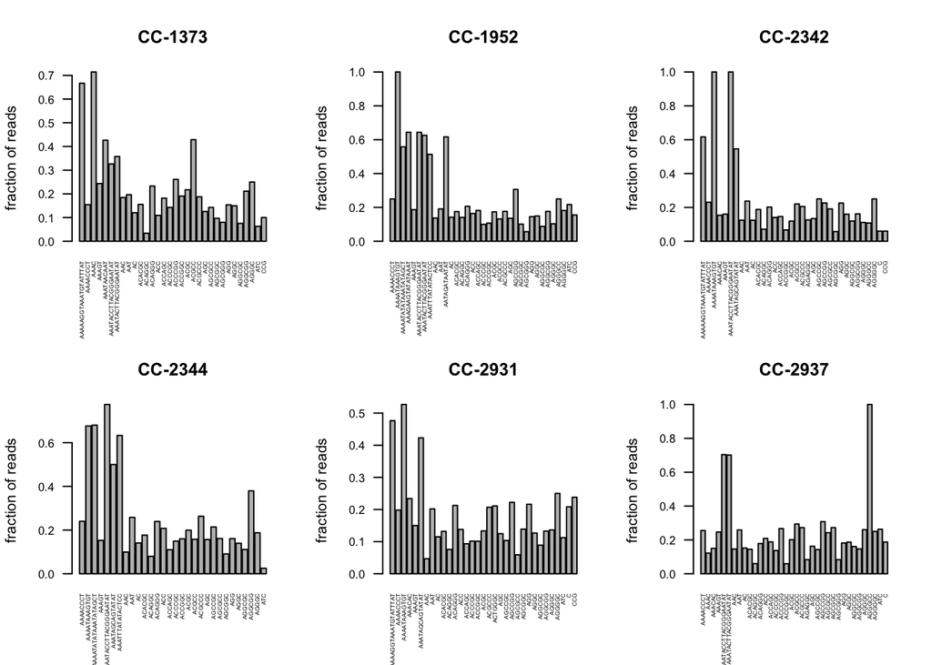

```r
# function that loops through all kmers and returns a vector
get_percent_summary <- function(totalreadsfile, inputrep) {
  kmers <- colnames(inputrep)[colnames(inputrep) %in% common.kmer.union]
  result <- c()
  for (i in 1:length(kmers)) {
    result <- c(result, get_percent_interspersed(totalreadsfile, inputrep, kmers[i]))
  }
  return(result)
}


int.summary_1373 <- get_percent_summary("ERR968344.total.reads.txt", CC_1373_MA7.rep)
int.summary_1952 <- get_percent_summary("ERR968352.total.reads.txt", CC_1952_MA2.rep)
int.summary_2342 <- get_percent_summary("ERR968369.total.reads.txt", CC_2342_MA7.rep)
int.summary_2344 <- get_percent_summary("ERR968391.total.reads.txt", CC_2344_MA15.rep)
int.summary_2931 <- get_percent_summary("ERR968392.total.reads.txt", CC_2931_MA1.rep)
int.summary_2937 <- get_percent_summary("ERR968409.total.reads.txt", CC_2937_MA4.rep)

par(mfrow=c(2,3))
barplot(int.summary_1373, names.arg=names(int.summary_1373), las=2, cex.names=0.4, cex.axis=0.8, main="CC-1373", ylab="fraction of reads")
barplot(int.summary_1952, names.arg=names(int.summary_1952), las=2, cex.names=0.4, cex.axis=0.8, main="CC-1952", ylab="fraction of reads")
barplot(int.summary_2342, names.arg=names(int.summary_2342), las=2, cex.names=0.4, cex.axis=0.8, main="CC-2342", ylab="fraction of reads")
barplot(int.summary_2344, names.arg=names(int.summary_2344), las=2, cex.names=0.4, cex.axis=0.8, main="CC-2344", ylab="fraction of reads")
barplot(int.summary_2931, names.arg=names(int.summary_2931), las=2, cex.names=0.4, cex.axis=0.8, main="CC-2931", ylab="fraction of reads")
barplot(int.summary_2937, names.arg=names(int.summary_2937), las=2, cex.names=0.4, cex.axis=0.8, main="CC-2937", ylab="fraction of reads")
```

```r
mean(int.summary_1373)
```

```
## [1] 0.218095
```

```r
mean(int.summary_1952)
```

```
## [1] 0.2608887
```

```r
mean(int.summary_2342)
```

```
## [1] 0.2291363
```

```r
mean(int.summary_2344)
```

```
## [1] 0.2508807
```

```r
mean(int.summary_2931)
```

```
## [1] 0.1798559
```

```r
mean(int.summary_2937)
```

```
## [1] 0.2410953
```

# How many, and what percent of chloroplast-like reads are interspersed with the telomere repeat?

```r
count_int_reads_telomere <- function(totalreadsfile, inputrep, kmer) {
  interspersion.matrix <- matrix(ncol=ncol(inputrep), nrow=nrow(inputrep))
  interspersion.matrix <- inputrep[colnames(inputrep) %in% common.kmer.union, rownames(inputrep) %in% common.kmer.union]

  pairwise.matrix <- matrix(ncol=ncol(interspersion.matrix), nrow=nrow(interspersion.matrix))

  rownames(pairwise.matrix) <- rownames(interspersion.matrix)
  colnames(pairwise.matrix) <- colnames(interspersion.matrix)

  for (i in 1:nrow(interspersion.matrix)) {
    pairwise.matrix[i,i] <- interspersion.matrix[i,i]
    for (j in (i+1):nrow(interspersion.matrix)) {
      if (j <= nrow(interspersion.matrix)) {
        sum <- interspersion.matrix[i,j] + interspersion.matrix[j,i]
        pairwise.matrix[i,j] <- sum
      }
    }
  }

  total.reads <- read.table(totalreadsfile, quote="\"", comment.char="")
  read.counts <- as.vector(total.reads[,1])
  names(read.counts) <- common.kmer.union
  read.counts_temp <- read.counts[names(read.counts) %in% colnames(pairwise.matrix)]
  read.counts <- read.counts_temp[order(match(names(read.counts_temp), colnames(pairwise.matrix)))]
  names(read.counts) == colnames(pairwise.matrix)

  res_1 <- pairwise.matrix[kmer, "AAAACCCT"]
  res_2 <- pairwise.matrix["AAAACCCT", kmer]
  temp <- c(res_1, res_2)
  res_12 <- temp[!is.na(temp)]
  res_3 <- res_12/read.counts[kmer]
  res_final <- c(res_12, res_3)
  print(res_final)
}


cp_kmers_1373 <- c("AAATACCTTACGGGAATAT", "AAATAACAAT", "AAATACTTACGGGAATAT")
for (i in 1:length(cp_kmers_1373)) {
  count_int_reads_telomere("ERR968344.total.reads.txt", CC_1373_MA7.rep, cp_kmers_1373[i])
}
```

```
##                     AAATACCTTACGGGAATAT
##         15.00000000          0.01054852
##              AAATAACAAT
## 44.00000000  0.02068641
##                    AAATACTTACGGGAATAT
##        23.00000000         0.01327945
```

```r
cp_kmers_1952 <- c("AATAGATAATAT", "AAATACTTACGGGAATAT", "AAAATATATAAATATAGCT", "AAAGAAGTATATAAAT", "AAATTTATATACTCC", "AAATACCTTACGGGAATAT")

for (i in 1:length(cp_kmers_1952)) {
  count_int_reads_telomere("ERR968352.total.reads.txt", CC_1952_MA2.rep, cp_kmers_1952[i])
}
```

```
##              AATAGATAATAT
##   2.00000000   0.01666667
##                    AAATACTTACGGGAATAT
##        21.00000000         0.05236908
##                     AAAATATATAAATATAGCT
##         41.00000000          0.04500549
##                  AAAGAAGTATATAAAT
##      56.00000000       0.05151794
##                 AAATTTATATACTCC
##     45.00000000      0.04285714
##                     AAATACCTTACGGGAATAT
##         56.00000000          0.05077063
```

```r
cp_kmers_2342 <- c("AAAAAGGTAAATGTATTTAT")
for (i in 1:length(cp_kmers_2342)) {
  count_int_reads_telomere("ERR968369.total.reads.txt", CC_2342_MA7.rep, cp_kmers_2342[i])
}
```

```
##                      AAAAAGGTAAATGTATTTAT
##          33.00000000           0.04004854
```

```r
cp_kmers_2344 <- c("AAAATAAAGTGT", "AAATACCTTACGGGAATAT", "AAATTTATATACTCC")
for (i in 1:length(cp_kmers_2344)) {
  count_int_reads_telomere("ERR968391.total.reads.txt", CC_2344_MA15.rep, cp_kmers_2344[i])
}
```

```
##              AAAATAAAGTGT
##  144.0000000    0.1165049
##                     AAATACCTTACGGGAATAT
##          34.0000000           0.1254613
##                 AAATTTATATACTCC
##      99.0000000       0.1062232
```

```r
cp_kmers_2931 <- c("AAAAAGGTAAATGTATTTAT", "AAATAGCAGTATAT", "AAAATAAAGTGT")
for (i in 1:length(cp_kmers_2931)) {
  count_int_reads_telomere("ERR968392.total.reads.txt", CC_2931_MA1.rep, cp_kmers_2931[i])
}
```

```
##                      AAAAAGGTAAATGTATTTAT
##              54.0000               0.0375
##                AAATAGCAGTATAT
##   140.00000000     0.03222094
##              AAAATAAAGTGT
##  56.00000000   0.03070175
```

```r
cp_kmers_2937 <- c("AAATACTTACGGGAATAT", "AAATACCTTACGGGAATAT")
for (i in 1:length(cp_kmers_2937)) {
  count_int_reads_telomere("ERR968409.total.reads.txt", CC_2937_MA4.rep, cp_kmers_2937[i])
}
```

```
##                    AAATACTTACGGGAATAT
##        16.00000000         0.04155844
##                     AAATACCTTACGGGAATAT
##         70.00000000          0.04745763
```

# Get kmers that are interspersed with each other

Kmers that have an interspersion metric > 0 are interspersed with each other.

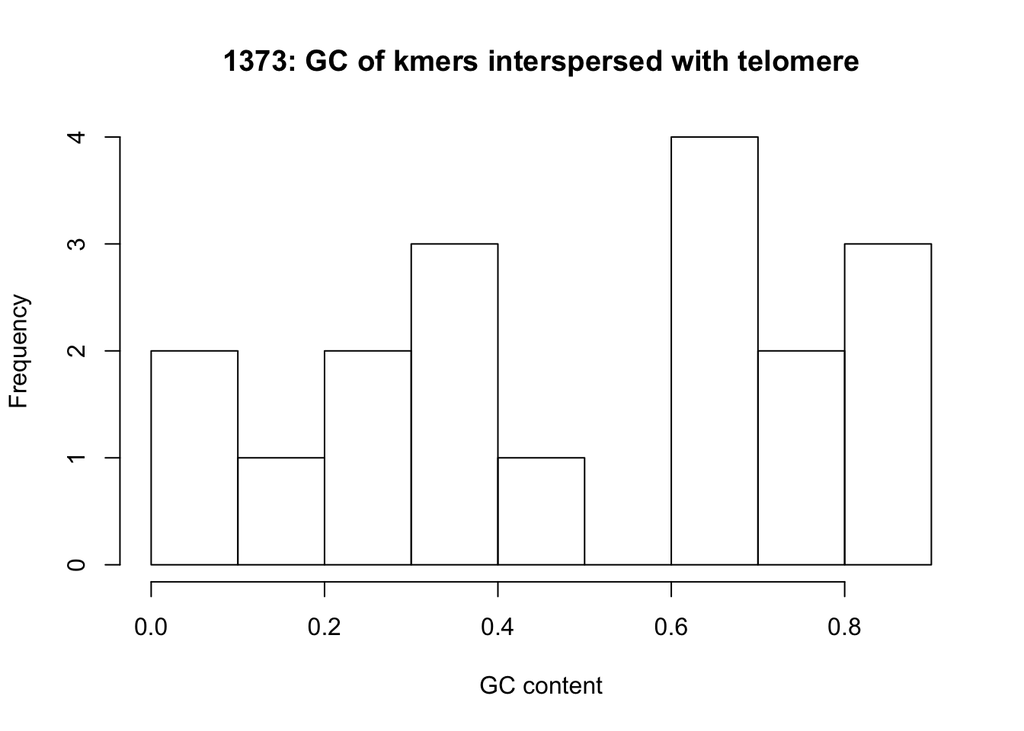

```r
# function that takes a kmer sequence and an interspersion matrix, and returns the kmers that are interspersed with the given input kmer (along with the corresponding interspersion metric)
get_interspersed_kmers <- function(kmer, input_mx) {
  kmer.index <- which(colnames(input_mx)==kmer)
  a <- input_mx[kmer.index,which(input_mx[kmer.index,] > 0)]
  a.names <- names(which(input_mx[kmer.index,] > 0))
  b <- input_mx[which(input_mx[,kmer.index] > 0), kmer.index]
  b.names <- names(which(input_mx[,kmer.index] > 0))
  ab <- c(a,b)
  ab.names <- c(a.names, b.names)
  names(ab) <- ab.names
  return(ab)
}

# function to calculate GC content of a kmer
Calc_GC_content <- function (kmer_string) {
  string <- BString(kmer_string)
  gc.content <- c(letterFrequency(string, letters=c("CG"), as.prob=F)/(length(string)))
  return(gc.content)
}

AAAACCCT_1373 <- get_interspersed_kmers("AAAACCCT", interspersion.metric.matrix_1373)
hist(sapply(names(AAAACCCT_1373), Calc_GC_content), xlab="GC content", main="1373: GC of kmers interspersed with telomere")
```

```r
length(AAAACCCT_1373)
```

```
## [1] 18
```

```r
AAAACCCT_1373
```

```
##            AAAACCCT                AAAC               AAAGT
##         0.011923276         0.008605674         0.002123171
##          AAATAACAAT AAATACCTTACGGGAATAT  AAATACTTACGGGAATAT
##         0.021722150         0.009056812         0.012583104
##                 AAT                  AC              ACACGC
##         0.001783364         0.025010773         0.003970172
##              ACAGGG              ACCAGC              ACCCGC
##         0.002243444         0.002594708         0.004968488
##              ACCGGC                ACGC                 AGC
##         0.002484244         0.003588814         0.005902937
##                AGGC              AGGCGG            AAAACCCT
##         0.004465265         0.003821375         0.011923276
```

```r
names(AAAACCCT_1373)
```

```
##  [1] "AAAACCCT"            "AAAC"                "AAAGT"
##  [4] "AAATAACAAT"          "AAATACCTTACGGGAATAT" "AAATACTTACGGGAATAT"
##  [7] "AAT"                 "AC"                  "ACACGC"
## [10] "ACAGGG"              "ACCAGC"              "ACCCGC"
## [13] "ACCGGC"              "ACGC"                "AGC"
## [16] "AGGC"                "AGGCGG"              "AAAACCCT"
```

```r
# these are the kmers that were found with Tandem Repeats Finder to be on the chloroplast assembly
cp_kmers <- c("AAAATAAAGTGT", "AAAATATATAAATATAGCT", "AAATACCTTACGGGAATAT")

# which kmers are interspersed with the telomere repeat in each of the ancestors?

AAAACCCT_1952 <- get_interspersed_kmers("AAAACCCT", interspersion.metric.matrix_1952)
AAAACCCT_1952
```

```
##            AAAACCCT AAAATATATAAATATAGCT    AAAGAAGTATATAAAT
##         0.011954573         0.023483439         0.029363667
## AAATACCTTACGGGAATAT  AAATACTTACGGGAATAT     AAATTTATATACTCC
##         0.029149916         0.018129430         0.024007940
##                 AAC                 AAT        AATAGATAATAT
##         0.002420761         0.005853606         0.003156286
##                  AC              ACACGC              ACAGGC
##         0.040180697         0.002442137         0.001935850
##              ACAGGG                 ACC              ACCAGC
##         0.001571608         0.006122761         0.005626665
##              ACCCGC                ACGC              ACGCCC
##         0.001822283         0.005068712         0.002420761
##                 AGC              AGCCGG              AGCGGC
##         0.009771145         0.002195539         0.001832492
##                 AGG                AGGC              AGGCGG
##         0.002691690         0.002067916         0.004771857
##                 ATC            AAAACCCT
##         0.001897571         0.011954573
```

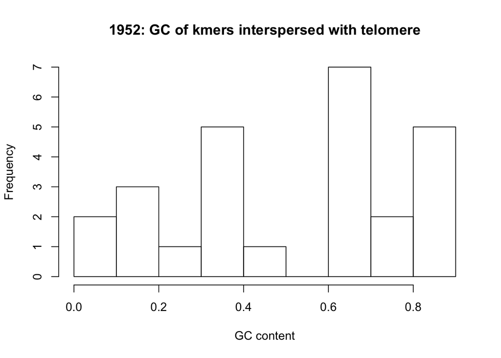

```r
hist(sapply(names(AAAACCCT_1952), Calc_GC_content), xlab="GC content", main="1952: GC of kmers interspersed with telomere")
```

```r
length(AAAACCCT_1952)
```

```
## [1] 26
```

```r
AAAACCCT_2342 <- get_interspersed_kmers("AAAACCCT", interspersion.metric.matrix_2342)
AAAACCCT_2342
```

```
##             AAAACCCT       AAATAGCAGTATAT                  AAT
##          0.015125324          0.034851927          0.007340212
##                   AC               ACACGC               ACAGGC
##          0.031726128          0.004396250          0.004622787
##               ACAGGG                  ACC                 ACGC
##          0.001459050          0.006001056          0.003443520
##                  AGC               AGCCGC               AGCCGG
##          0.008527874          0.009860742          0.002155643
##               AGCGGC                 AGGC               AGGGCC
##          0.003513859          0.003114350          0.004116691
## AAAAAGGTAAATGTATTTAT             AAAACCCT
##          0.023898391          0.015125324
```

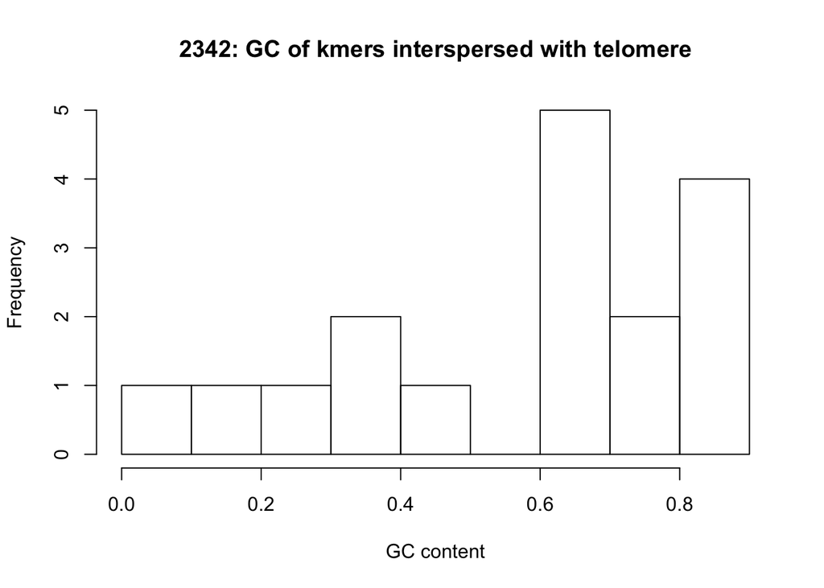

```r
hist(sapply(names(AAAACCCT_2342), Calc_GC_content), xlab="GC content", main="2342: GC of kmers interspersed with telomere")
```

```r
length(AAAACCCT_2342)
```

```
## [1] 17
```

```r
AAAACCCT_2344 <- get_interspersed_kmers("AAAACCCT", interspersion.metric.matrix_2344)
AAAACCCT_2344
```

```
##            AAAACCCT        AAAATAAAGTGT AAAATATATAAATATAGCT
##        0.0187025132        0.0495106076        0.0079758379
## AAATACCTTACGGGAATAT     AAATTTATATACTCC                 AAC
##        0.0249654427        0.0391987518        0.0030882725
##                 AAT                  AC              ACACGC
##        0.0116709184        0.0588778490        0.0057378679
##              ACAGGC              ACAGGG                 ACC
##        0.0009111475        0.0062682529        0.0048702880
##              ACCAGC              ACCGGC                ACGC
##        0.0038612859        0.0013957716        0.0063183613
##              ACGCCC                 AGC              AGCGCC
##        0.0039217797        0.0180983973        0.0021710216
##              AGCGGC                 AGG                AGGC
##        0.0032598202        0.0025918829        0.0049655446
##              AGGCGG               AGGGC            AAAACCCT
##        0.0069249666        0.0015109671        0.0187025132
```

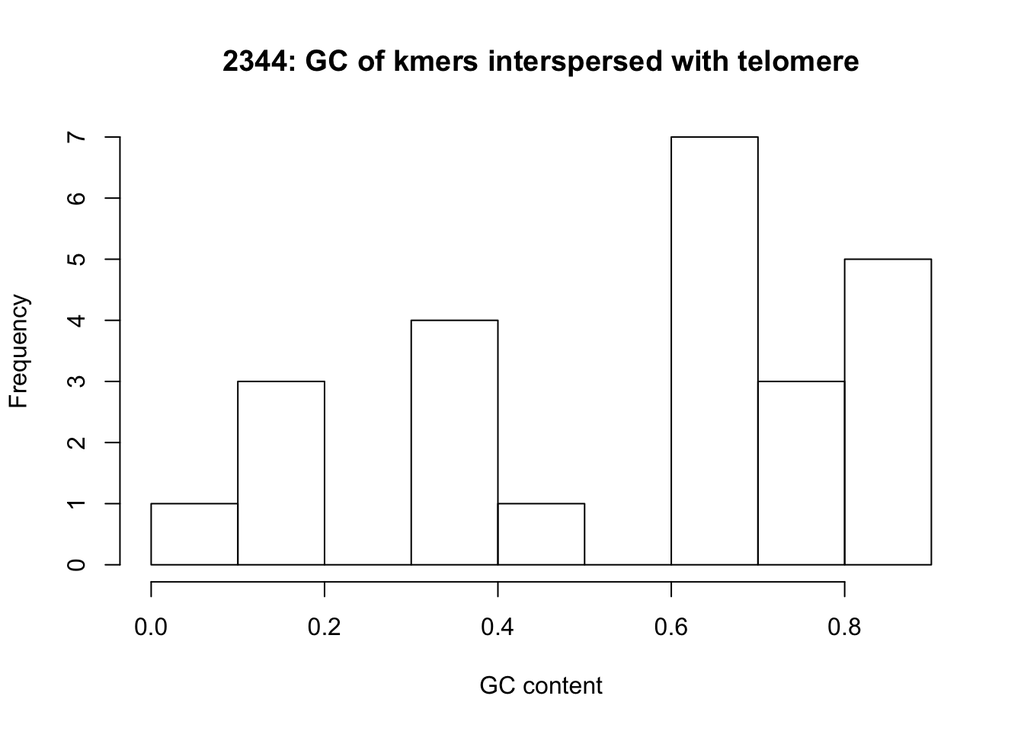

```r
hist(sapply(names(AAAACCCT_2344), Calc_GC_content), xlab="GC content", main="2344: GC of kmers interspersed with telomere")
```

```r
length(AAAACCCT_2344)
```

```
## [1] 24
```

```r
AAAACCCT_2931 <- get_interspersed_kmers("AAAACCCT", interspersion.metric.matrix_2931)
AAAACCCT_2931
```

```
##             AAAACCCT         AAAATAAAGTGT                AAAGT
##         0.0128336756         0.0210071016         0.0014625136
##       AAATAGCAGTATAT                  AAT                   AC
##         0.0340270008         0.0069921522         0.0303415649
##               ACACGC               ACAGGC               ACAGGG
##         0.0038086587         0.0006722276         0.0055406221
##                  ACC               ACCAGC               ACCCGC
##         0.0013304744         0.0021361378         0.0019287058
##                 ACGC               ACGCCC              ACTGGGC
##         0.0023882747         0.0021036647         0.0016887652
##                  AGC                  AGG                 AGGC
##         0.0080889023         0.0045619476         0.0036224809
##               AGGCGG                AGGGC                  ATC
##         0.0010320055         0.0024152617         0.0016183688
## AAAAAGGTAAATGTATTTAT             AAAACCCT
##         0.0227983302         0.0128336756
```

```r
length(AAAACCCT_2931)
```

```
## [1] 23
```

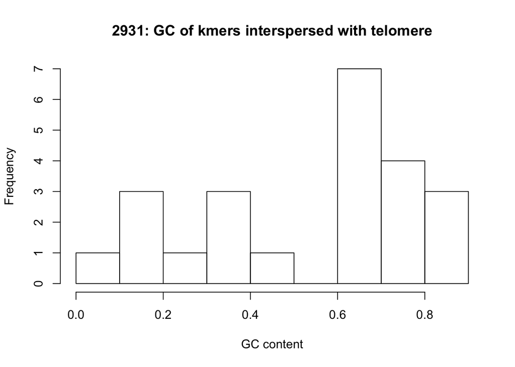

```r
hist(sapply(names(AAAACCCT_2931), Calc_GC_content), xlab="GC content", main="2931: GC of kmers interspersed with telomere")
```

```r
AAAACCCT_2937 <- get_interspersed_kmers("AAAACCCT", interspersion.metric.matrix_2937)
AAAACCCT_2937
```

```
##            AAAACCCT              AAACAC               AAAGT
##         0.018421967         0.002084419         0.003745406
## AAATACCTTACGGGAATAT  AAATACTTACGGGAATAT                 AAC
##         0.033980683         0.015202664         0.001062318
##                 AAT                  AC              ACACGC
##         0.006630477         0.039242257         0.005560279
##              ACAGGC              ACAGGG                 ACC
##         0.001221384         0.005326746         0.005243926
##              ACCAGC              ACCCGC              ACCCGG
##         0.001179126         0.001845993         0.003403842
##              ACCGGC                ACGC              ACGCCC
##         0.001716284         0.007662478         0.005621261
##                 AGC              AGCCGC              AGCCGG
##         0.008986552         0.009965430         0.005170808
##              AGCGGC                 AGG                AGGC
##         0.004589740         0.001289606         0.005262481
##              AGGCGC              AGGCGG               AGGGC
##         0.001559057         0.003429340         0.001902806
##            AAAACCCT
##         0.018421967
```

```r
length(AAAACCCT_2937)
```

```
## [1] 28
```

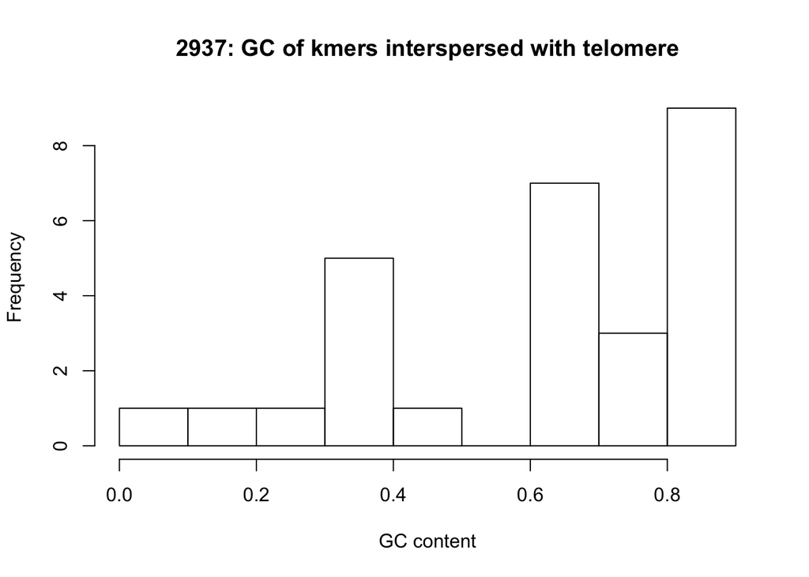

```r
hist(sapply(names(AAAACCCT_2937), Calc_GC_content), xlab="GC content", main="2937: GC of kmers interspersed with telomere")
```

```r
possible_cp_telomere <- c("AAATAACAAT", "AAATACCTTACGGGAATAT", "AAATACTTACGGGAATAT", "AAAATATATAAATATAGCT", "AAAGAAGTATATAAAT", "AAATACCTTACGGGAATAT", "AAATACTTACGGGAATAT", "AAATTTATATACTCC", "AATAGATAATAT", "AAATAGCAGTATAT", "AAAAAGGTAAATGTATTTAT", "AAAATAAAGTGT", "AAAATATATAAATATAGCT", "AAATACCTTACGGGAATAT", "AAATTTATATACTCC", "AAAATAAAGTGT", "AAATAGCAGTATAT", "AAAAAGGTAAATGTATTTAT", "AAATACCTTACGGGAATAT", "AAATACTTACGGGAATAT")

length(possible_cp_telomere)
```

```
## [1] 20
```

```r
cp_kmers %in% possible_cp_telomere
```

```
## [1] TRUE TRUE TRUE
```

```r
summary(as.factor(possible_cp_telomere))
```

```
## AAAAAGGTAAATGTATTTAT         AAAATAAAGTGT  AAAATATATAAATATAGCT
##                    2                    2                    2
##     AAAGAAGTATATAAAT           AAATAACAAT  AAATACCTTACGGGAATAT
##                    1                    1                    4
##   AAATACTTACGGGAATAT       AAATAGCAGTATAT      AAATTTATATACTCC
##                    3                    2                    2
##         AATAGATAATAT
##                    1
```

** 40/46 kmers are interspersed with the telomere to some extent **

```r
all_telomere_kmers <- c(names(AAAACCCT_1373), names(AAAACCCT_1952), names(AAAACCCT_2342), names(AAAACCCT_2344), names(AAAACCCT_2931), names(AAAACCCT_2937) )

all_telomere_kmers_fac <- as.factor(all_telomere_kmers)
all_telomere_kmers_names <- names(summary(all_telomere_kmers_fac))

setdiff(common.kmer.union, all_telomere_kmers_names )
```

```
## [1] "C"      "CCG"    "AGCGGG" "ACGCC"  "AGGGGC" "AGAGGC"
```

Check interspersion of putative chloroplast kmers

```r
AAATACCTTACGGGAATAT_1373 <- get_interspersed_kmers("AAATACCTTACGGGAATAT", interspersion.metric.matrix_1373)
AAATACCTTACGGGAATAT_1373
```

```
## AAATACCTTACGGGAATAT  AAATACTTACGGGAATAT                 AAT
##         0.023206751         0.064994473         0.006231286
##                  AC              ACACGC              ACCAGC
##         0.023345477         0.004624083         0.003022072
##              ACCCGG                ACGC              ACGCCC
##         0.005529505         0.002089957         0.006629644
##                 AGC                AGGC              AGGCGG
##         0.011294949         0.006934294         0.002225389
##            AAAACCCT               AAAGT          AAATAACAAT
##         0.009056812         0.004945740         0.081074741
## AAATACCTTACGGGAATAT
##         0.023206751
```

```r
AAATACCTTACGGGAATAT_1952 <- get_interspersed_kmers("AAATACCTTACGGGAATAT", interspersion.metric.matrix_1952)
AAATACCTTACGGGAATAT_1952
```

```
## AAATACCTTACGGGAATAT  AAATACTTACGGGAATAT     AAATTTATATACTCC
##         0.029011786         0.034583416         0.039956372
##                 AAC                 AAT        AATAGATAATAT
##         0.004216258         0.010195269         0.024737974
##                  AC              ACACGC              ACAGGC
##         0.047933575         0.002835659         0.001685842
##              ACAGGG                 ACC              ACCAGC
##         0.008211846         0.005332030         0.003920002
##                ACGC              ACGCCC                 AGC
##         0.006305867         0.004216258         0.018263731
##              AGCGGC                 AGG                AGGC
##         0.006383329         0.002344068         0.006002842
##              AGGCGG                 ATC            AAAACCCT
##         0.006233384         0.006610026         0.029149916
##        AAAATAAAGTGT AAAATATATAAATATAGCT    AAAGAAGTATATAAAT
##         0.042582116         0.061850718         0.059362315
## AAATACCTTACGGGAATAT
##         0.029011786
```

```r
AAATACCTTACGGGAATAT_2342 <- get_interspersed_kmers("AAATACCTTACGGGAATAT", interspersion.metric.matrix_2342)
AAATACCTTACGGGAATAT_2342
```

```
## named numeric(0)
```

```r
AAATACCTTACGGGAATAT_2344 <- get_interspersed_kmers("AAATACCTTACGGGAATAT", interspersion.metric.matrix_2344)
AAATACCTTACGGGAATAT_2344
```

```
## AAATACCTTACGGGAATAT     AAATTTATATACTCC                 AAT
##         0.007380074         0.031836651         0.010473392
##                  AC              ACACGC              ACAGGG
##         0.033841990         0.005242739         0.003937557
##                 ACC                 AGC                AGGC
##         0.004895026         0.005512220         0.002772648
##            AAAACCCT        AAAATAAAGTGT AAAATATATAAATATAGCT
##         0.024965443         0.039740557         0.005010219
## AAATACCTTACGGGAATAT
##         0.007380074
```

```r
AAATACCTTACGGGAATAT_2931 <- get_interspersed_kmers("AAATACCTTACGGGAATAT", interspersion.metric.matrix_2931)
AAATACCTTACGGGAATAT_2931
```

```
## numeric(0)
```

```r
AAATACCTTACGGGAATAT_2937 <- get_interspersed_kmers("AAATACCTTACGGGAATAT", interspersion.metric.matrix_2937)
AAATACCTTACGGGAATAT_2937
```

```
## AAATACCTTACGGGAATAT  AAATACTTACGGGAATAT                 AAC
##         0.042711864         0.049099305         0.001483640
##                 AAT                  AC              ACACGC
##         0.017362809         0.081097144         0.017920431
##              ACAGGC              ACAGGG                 ACC
##         0.006823167         0.009299208         0.017576876
##              ACCAGC              ACCCGC              ACCGGC
##         0.001646774         0.002578125         0.002396972
##                ACGC               ACGCC                 AGC
##         0.013911901         0.004465443         0.026752751
##              AGCGCC              AGCGGC                 AGG
##         0.009065192         0.009615088         0.005403213
##                AGGC            AAAACCCT                AAAC
##         0.008399558         0.033980683         0.002875392
##               AAAGT AAATACCTTACGGGAATAT
##         0.008718094         0.042711864
```

```r
length(AAATACCTTACGGGAATAT_2937)
```

```
## [1] 23
```

## What kmers are interspersed with itself (in long arrays)

```r
get_self_score <- function (kmer, input_mx) {
  interspersed <- get_interspersed_kmers(kmer, input_mx)
  return (interspersed[kmer])
}

a <- get_self_score("AAAACCCT", interspersion.metric.matrix_1373)
colnames(interspersion.metric.matrix_1373)
```

```
##  [1] "AAAAAGGTAAATGTATTTAT" "AAAACCCT"             "AAAC"
##  [4] "AAAGT"                "AAATAACAAT"           "AAATACCTTACGGGAATAT"
##  [7] "AAATACTTACGGGAATAT"   "AAC"                  "AAT"
## [10] "AC"                   "ACACGC"               "ACAGGC"
## [13] "ACAGGG"               "ACC"                  "ACCAGC"
## [16] "ACCCGC"               "ACCCGG"               "ACCGGC"
## [19] "ACGC"                 "ACGCC"                "ACGCCC"
## [22] "AGC"                  "AGCGCC"               "AGCGGC"
## [25] "AGCGGG"               "AGG"                  "AGGC"
## [28] "AGGCGC"               "AGGCGG"               "AGGGC"
## [31] "ATC"                  "CCG"
```

```r
b <- get_self_score("AGGC", interspersion.metric.matrix_1373)


self_scores_1373 <- c()
for (i in 1:ncol(interspersion.metric.matrix_1373)){
  self_scores_1373 <- c(self_scores_1373, get_self_score(colnames(interspersion.metric.matrix_1373)[i], interspersion.metric.matrix_1373))
}
long_arrays_1373 <- names( which(!is.na(self_scores_1373)))

self_scores_1952 <- c()
for (i in 1:ncol(interspersion.metric.matrix_1952)){
  self_scores_1952 <- c(self_scores_1952, get_self_score(colnames(interspersion.metric.matrix_1952)[i], interspersion.metric.matrix_1952))
}
long_arrays_1952 <- names( which(!is.na(self_scores_1952)))

self_scores_2342 <- c()
for (i in 1:ncol(interspersion.metric.matrix_2342)){
  self_scores_2342 <- c(self_scores_2342, get_self_score(colnames(interspersion.metric.matrix_2342)[i], interspersion.metric.matrix_2342))
}
(long_arrays_2342 <- names( which(!is.na(self_scores_2342))))
```

```
## [1] "AAAAAGGTAAATGTATTTAT" "AAAACCCT"             "AAATAGCAGTATAT"
## [4] "AAT"                  "AC"                   "AGC"
## [7] "AGGC"
```

```r
self_scores_2344 <- c()
for (i in 1:ncol(interspersion.metric.matrix_2344)){
  self_scores_2344 <- c(self_scores_2344, get_self_score(colnames(interspersion.metric.matrix_2344)[i], interspersion.metric.matrix_2344))
}
(long_arrays_2344 <- names( which(!is.na(self_scores_2344))))
```

```
## [1] "AAAACCCT"            "AAAATAAAGTGT"        "AAATACCTTACGGGAATAT"
## [4] "AAATTTATATACTCC"     "AC"                  "ACAGGC"
## [7] "AGC"                 "AGGCGG"
```

```r
self_scores_2931 <- c()
for (i in 1:ncol(interspersion.metric.matrix_2931)){
  self_scores_2931 <- c(self_scores_2931, get_self_score(colnames(interspersion.metric.matrix_2931)[i], interspersion.metric.matrix_2931))
}
(long_arrays_2931 <- names( which(!is.na(self_scores_2931))))
```

```
## [1] "AAAAAGGTAAATGTATTTAT" "AAAACCCT"             "AAAATAAAGTGT"
## [4] "AAATAGCAGTATAT"       "AC"                   "ACACGC"
## [7] "ACTGGGC"              "AGC"
```

```r
self_scores_2937 <- c()
for (i in 1:ncol(interspersion.metric.matrix_2937)){
  self_scores_2937 <- c(self_scores_2937, get_self_score(colnames(interspersion.metric.matrix_2937)[i], interspersion.metric.matrix_2937))
}
(long_arrays_2937 <- names( which(!is.na(self_scores_2937))))
```

```
## [1] "AAAACCCT"            "AAATACCTTACGGGAATAT" "AAATACTTACGGGAATAT"
## [4] "AAT"                 "AC"                  "ACACGC"
## [7] "AGC"                 "AGGCGC"
```

```r
long_arrays_all <- c(long_arrays_1373, long_arrays_2342, long_arrays_1952, long_arrays_2344, long_arrays_2931, long_arrays_2937)

long_arrays_factor <- as.factor(long_arrays_all)
summary(long_arrays_factor)
```

```
## AAAAAGGTAAATGTATTTAT             AAAACCCT         AAAATAAAGTGT
##                    2                    6                    2
##  AAAATATATAAATATAGCT     AAAGAAGTATATAAAT           AAATAACAAT
##                    1                    1                    1
##  AAATACCTTACGGGAATAT   AAATACTTACGGGAATAT       AAATAGCAGTATAT
##                    4                    3                    2
##      AAATTTATATACTCC                  AAT                   AC
##                    2                    2                    6
##               ACACGC               ACAGGC                 ACGC
##                    2                    1                    1
##              ACTGGGC                  AGC                 AGGC
##                    1                    6                    1
##               AGGCGC               AGGCGG
##                    1                    1
```

```r
length(summary(long_arrays_factor))
```

```
## [1] 20
```

```r
## great, 20 of the kmers are interspersed at a high level. Save these kmers and bring them into the mutation rate script.

# you should save them as a list and import into the other file.
kmers_long_arrays_byline <- list(long_arrays_1373, long_arrays_1952,long_arrays_2342, long_arrays_2344, long_arrays_2931, long_arrays_2937)

#write(names(summary(long_arrays_factor)), "/Users/jullienflynn/Documents/AndyLab/Chlamy/PostReview/kmers_long_arrays.txt")

save(kmers_long_arrays_byline, file="/Users/jullienflynn/Documents/AndyLab/Chlamy/PostReview/kmers_long_arrays_byline.txt")
```

## What is the interspersion patterns of the repeats that have interesting patterns of interspersion in the correlation plots?

```r
(AGGC_1373 <- get_interspersed_kmers("AGGC", interspersion.metric.matrix_1373))
```

```
##            AAAACCCT               AAAGT          AAATAACAAT
##         0.004465265         0.006095975         0.005669808
## AAATACCTTACGGGAATAT  AAATACTTACGGGAATAT                  AC
##         0.006934294         0.001570790         0.008148659
##              ACACGC              ACCGGC                 AGC
##         0.003799673         0.007132675         0.001210593
##                 AGG
##         0.010467905
```

```r
(AGGC_1952 <- get_interspersed_kmers("AGGC", interspersion.metric.matrix_1952))
```

```
##            AAAACCCT AAAATATATAAATATAGCT    AAAGAAGTATATAAAT
##         0.002067916         0.003963116         0.002418744
## AAATACCTTACGGGAATAT  AAATACTTACGGGAATAT     AAATTTATATACTCC
##         0.006002842         0.003982286         0.003691486
##        AATAGATAATAT                  AC                 ACC
##         0.003639855         0.013541319         0.002353606
##              ACCAGC                ACGC                 AGC
##         0.002595486         0.001670080         0.003847665
```

```r
(AGGC_2342 <- get_interspersed_kmers("AGGC", interspersion.metric.matrix_2342))
```

```
##                 AGGC               AGGGCC               AGGGGC
##          0.002493766          0.004944561          0.014415748
## AAAAAGGTAAATGTATTTAT             AAAACCCT                AAAGT
##          0.005218978          0.003114350          0.005766299
##       AAATAGCAGTATAT                   AC                  ACC
##          0.005232585          0.010812163          0.003603937
##                 ACGC                ACGCC                  AGC
##          0.002757344          0.006501324          0.003151642
##                 AGGC
##          0.002493766
```

```r
(AGGC_2344 <- get_interspersed_kmers("AGGC", interspersion.metric.matrix_2344))
```

```
##              AGGCGG            AAAACCCT        AAAATAAAGTGT
##         0.006537205         0.004965545         0.005193141
## AAAATATATAAATATAGCT AAATACCTTACGGGAATAT     AAATTTATATACTCC
##         0.003764616         0.002772648         0.002990208
##                  AC              ACAGGG                ACGC
##         0.009098253         0.002958632         0.004771653
##                 AGC
##         0.001380605
```

```r
(AGGC_2931 <- get_interspersed_kmers("AGGC", interspersion.metric.matrix_2931))
```

```
## AAAAAGGTAAATGTATTTAT             AAAACCCT         AAAATAAAGTGT
##          0.003575078          0.003622481          0.004235387
##       AAATAGCAGTATAT                   AC               ACAGGG
##          0.007546462          0.007217126          0.002606528
##               ACCAGC                  AGC                  AGG
##          0.003014771          0.002140503          0.004292241
```

```r
(AGGC_2937 <- get_interspersed_kmers("AGGC", interspersion.metric.matrix_2937))
```

```
##               AGGGC            AAAACCCT AAATACCTTACGGGAATAT
##         0.004115540         0.005262481         0.008399558
##  AAATACTTACGGGAATAT                  AC                 ACC
##         0.004110192         0.014382377         0.002268396
##              ACCAGC                 AGC                 AGG
##         0.002550307         0.006137947         0.002789262
```

```r
(AGGCGC_1373 <- get_interspersed_kmers("AGGCGC", interspersion.metric.matrix_1373))
```

```
##  AAATAACAAT          AC
## 0.002248406 0.004847121
```

```r
(AGGCGC_1952 <- get_interspersed_kmers("AGGCGC", interspersion.metric.matrix_1952))
```

```
##         AAC          AC         AGC
## 0.006262243 0.004271632 0.001233018
```

```r
(AGGCGC_2342 <- get_interspersed_kmers("AGGCGC", interspersion.metric.matrix_2342))
```

```
## AAAAAGGTAAATGTATTTAT       AAATAGCAGTATAT                   AC
##          0.004255974          0.002560242          0.003225771
##                  AGC
##          0.001927577
```

```r
(AGGCGC_2344 <- get_interspersed_kmers("AGGCGC", interspersion.metric.matrix_2344))
```

```
##          AC
## 0.003809586
```

```r
(AGGCGC_2931 <- get_interspersed_kmers("AGGCGC", interspersion.metric.matrix_2931))
```

```
## AAAAAGGTAAATGTATTTAT                   AC               ACCAGC
##          0.005555556          0.001121518          0.007027284
##                  AGC
##          0.003326272
```

```r
(AGGCGC_2937 <- get_interspersed_kmers("AGGCGC", interspersion.metric.matrix_2937))
```

```
##      AGGCGC    AAAACCCT          AC      ACACGC         AGC      AGGCGC
## 0.006993007 0.001559057 0.006721433 0.001918471 0.002121492 0.006993007
```

```r
(ACCAGC_1373 <- get_interspersed_kmers("ACCAGC", interspersion.metric.matrix_1373))
```

```
##            AAAACCCT AAATACCTTACGGGAATAT  AAATACTTACGGGAATAT
##         0.002594708         0.003022072         0.002738298
##                  AC
##         0.008878278
```

```r
(ACCAGC_1952 <- get_interspersed_kmers("ACCAGC", interspersion.metric.matrix_1952))
```

```
##                 AGC                AGGC            AAAACCCT
##         0.002692092         0.002595486         0.005626665
##    AAAGAAGTATATAAAT AAATACCTTACGGGAATAT  AAATACTTACGGGAATAT
##         0.003948746         0.003920002         0.003250662
##     AAATTTATATACTCC                 AAT                  AC
##         0.002008859         0.003673493         0.008635556
```

```r
(AGGCGC_2342 <- get_interspersed_kmers("AGGCGC", interspersion.metric.matrix_2342))
```

```
## AAAAAGGTAAATGTATTTAT       AAATAGCAGTATAT                   AC
##          0.004255974          0.002560242          0.003225771
##                  AGC
##          0.001927577
```

```r
(AGGCGC_2344 <- get_interspersed_kmers("AGGCGC", interspersion.metric.matrix_2344))
```

```
##          AC
## 0.003809586
```

```r
(AGGCGC_2931 <- get_interspersed_kmers("AGGCGC", interspersion.metric.matrix_2931))
```

```
## AAAAAGGTAAATGTATTTAT                   AC               ACCAGC
##          0.005555556          0.001121518          0.007027284
##                  AGC
##          0.003326272
```

```r
(AGGCGC_2937 <- get_interspersed_kmers("AGGCGC", interspersion.metric.matrix_2937))
```

```
##      AGGCGC    AAAACCCT          AC      ACACGC         AGC      AGGCGC
## 0.006993007 0.001559057 0.006721433 0.001918471 0.002121492 0.006993007
```

```r
(ACAGGC_1373 <- get_interspersed_kmers("ACAGGC", interspersion.metric.matrix_1373))
```

```
##  AAATAACAAT          AC
## 0.002822866 0.001014257
```

```r
(ACAGGC_1952 <- get_interspersed_kmers("ACAGGC", interspersion.metric.matrix_1952))
```

```
##                 ACC                ACGC                 AGC
##         0.003304941         0.002345132         0.002315530
##            AAAACCCT AAAATATATAAATATAGCT    AAAGAAGTATATAAAT
##         0.001935850         0.001855007         0.005094612
## AAATACCTTACGGGAATAT  AAATACTTACGGGAATAT        AATAGATAATAT
##         0.001685842         0.005591940         0.005111096
##                  AC
##         0.007724748
```

```r
(ACAGGC_2342 <- get_interspersed_kmers("ACAGGC", interspersion.metric.matrix_2342))
```

```
##       AAAACCCT AAATAGCAGTATAT             AC
##    0.004622787    0.006213593    0.001957200
```

```r
(ACAGGC_2344 <- get_interspersed_kmers("ACAGGC", interspersion.metric.matrix_2344))
```

```
##          ACAGGC             AGC        AAAACCCT AAATTTATATACTCC
##    0.0056818182    0.0011399967    0.0009111475    0.0024690831
##              AC          ACAGGC
##    0.0030821068    0.0056818182
```

```r
(ACAGGC_2931 <- get_interspersed_kmers("ACAGGC", interspersion.metric.matrix_2931))
```

```
##               ACAGGG AAAAAGGTAAATGTATTTAT             AAAACCCT
##         0.0024184805         0.0011057185         0.0006722276
##         AAAATAAAGTGT       AAATAGCAGTATAT                   AC
##         0.0049122835         0.0095482152         0.0040178692
```

```r
(ACAGGC_2937 <- get_interspersed_kmers("ACAGGC", interspersion.metric.matrix_2937))
```

```
##            AAAACCCT AAATACCTTACGGGAATAT                  AC
##         0.001221384         0.006823167         0.002961928
```

```r
(AC_1373 <- get_interspersed_kmers("AC", interspersion.metric.matrix_1373))
```

```
##                   AC               ACACGC               ACAGGC
##          0.041939791          0.008603633          0.001014257
##               ACAGGG                  ACC               ACCAGC
##          0.010746908          0.005252460          0.008878278
##               ACCCGC               ACCCGG               ACCGGC
##          0.003400122          0.003248929          0.005950213
##                 ACGC                ACGCC               ACGCCC
##          0.011665807          0.002944592          0.003895329
##                  AGC               AGCGCC               AGCGGC
##          0.029575644          0.003950584          0.002798487
##               AGCGGG                  AGG                 AGGC
##          0.003116263          0.004990014          0.008148659
##               AGGCGC               AGGCGG                AGGGC
##          0.004847121          0.008499107          0.005226132
##                  ATC                  CCG AAAAAGGTAAATGTATTTAT
##          0.004436739          0.001742044          0.004497938
##             AAAACCCT                 AAAC                AAAGT
##          0.025010773          0.008833775          0.010170756
##           AAATAACAAT  AAATACCTTACGGGAATAT   AAATACTTACGGGAATAT
##          0.046116147          0.023345477          0.034069954
##                  AAC                  AAT                   AC
##          0.007676363          0.009763382          0.041939791
```

```r
length(AC_1373)
```

```
## [1] 33
```

```r
# all the kmers that are interspersed with others are interspersed with AC
```

# Get number of other kmers each kmer is interspersed with

```r
# function returns number of kmers a kmer with a given index is interspersed with
get_total_interspersion <- function(kmer, input_mx ) {

  if (kmer.index == 1) {
    return (sum(interspersion.metric.matrix[kmer.index, (kmer.index + 1):ncol(interspersion.metric.matrix) ]))
  } else if (kmer.index == ncol(interspersion.metric.matrix)) {
    return (sum(interspersion.metric.matrix[1:(kmer.index-1), kmer.index ]))
  } else {
    total_rows <- sum(interspersion.metric.matrix[kmer.index, (kmer.index + 1):ncol(interspersion.metric.matrix) ])
    total_cols <- sum(interspersion.metric.matrix[1:(kmer.index-1), kmer.index ])
    total <- total_rows + total_cols
    return (total)
  }
}
```

Look at the kmers that are interesting because their interspersion matrices - sometimes a positive correlation and sometimes negative. Make a bar chart par(mfrow)

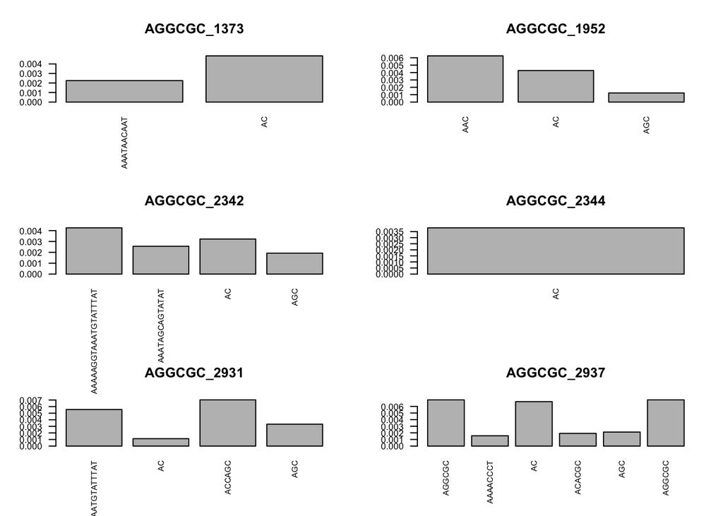

```r
par(mfrow=c(3,2))
barplot(AGGCGC_1373, names.arg=names(AGGCGC_1373), las=2, cex.names=0.7, cex.axis=0.8, main="AGGCGC_1373")
barplot(AGGCGC_1952, names.arg=names(AGGCGC_1952), las=2, cex.names=0.7, cex.axis=0.8, main="AGGCGC_1952")
barplot(AGGCGC_2342, names.arg=names(AGGCGC_2342), las=2, cex.names=0.7, cex.axis=0.8, main="AGGCGC_2342")
barplot(AGGCGC_2344, names.arg=names(AGGCGC_2344), las=2, cex.names=0.7, cex.axis=0.8, main="AGGCGC_2344")
barplot(AGGCGC_2931, names.arg=names(AGGCGC_2931), las=2, cex.names=0.7, cex.axis=0.8, main="AGGCGC_2931")
barplot(AGGCGC_2937, names.arg=names(AGGCGC_2937), las=2, cex.names=0.7, cex.axis=0.8, main="AGGCGC_2937")
```

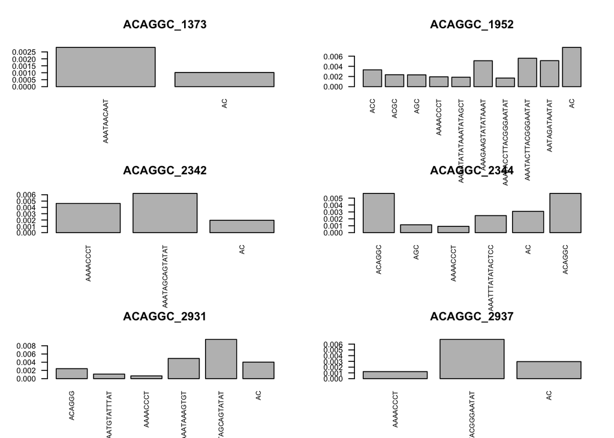

```r
barplot(ACAGGC_1373, names.arg=names(ACAGGC_1373), las=2, cex.names=0.7, cex.axis=0.8, main="ACAGGC_1373")
barplot(ACAGGC_1952, names.arg=names(ACAGGC_1952), las=2, cex.names=0.7, cex.axis=0.8, main="ACAGGC_1952")
barplot(ACAGGC_2342, names.arg=names(ACAGGC_2342), las=2, cex.names=0.7, cex.axis=0.8, main="ACAGGC_2342")
barplot(ACAGGC_2344, names.arg=names(ACAGGC_2344), las=2, cex.names=0.7, cex.axis=0.8, main="ACAGGC_2344")
barplot(ACAGGC_2931, names.arg=names(ACAGGC_2931), las=2, cex.names=0.7, cex.axis=0.8, main="ACAGGC_2931")
barplot(ACAGGC_2937, names.arg=names(ACAGGC_2937), las=2, cex.names=0.7, cex.axis=0.8, main="ACAGGC_2937")
```

```r
library(ggplot2)
temp <- upper.tri(interspersion.metric.matrix_1373, diag = T)
# you already have triangular matrix
```

# Kmers that are related closely by sequence (see Figure 3 in manuscript) - do they have interesting patterns of interspersion?

```r
related_kmers_AG <- c("ACGC", "ACGCC", "ACGCCC", "AGGC", "AGGCGG", "AGGCGC","AGGGC",  "AGGGGC", "AGAGGC", "AGCGGC", "AGCGGG", "AGCCGC", "AGCGCC", "AGCCGG", "AGGGCC")

related_kmers_AC <- c("ACCGGC", "ACCCGC", "ACACGC", "ACAGGC", "ACAGGG", "ACCAGC", "ACCCGG", "ACTGGGC")

related_kmers_AG_1373 <- related_kmers_AG[related_kmers_AG %in% colnames(interspersion.metric.matrix_1373)]
interspersion.metric.matrix_1373[related_kmers_AG_1373, related_kmers_AG_1373]
```

```
##              ACGC ACGCC ACGCCC AGGC AGGCGG AGGCGC AGGGC AGCGGC AGCGGG
## ACGC   0.00621118     0      0    0      0      0     0      0      0
## ACGCC          NA     0      0    0      0      0     0      0      0
## ACGCCC         NA    NA      0    0      0      0     0      0      0
## AGGC           NA    NA     NA    0      0      0     0     NA     NA
## AGGCGG         NA    NA     NA   NA      0     NA     0     NA     NA
## AGGCGC         NA    NA     NA   NA      0      0     0     NA     NA
## AGGGC          NA    NA     NA   NA     NA     NA     0     NA     NA
## AGCGGC         NA    NA     NA    0      0      0     0      0      0
## AGCGGG         NA    NA     NA    0      0      0     0     NA      0
## AGCGCC         NA    NA     NA    0      0      0     0      0      0
##           AGCGCC
## ACGC   0.0133215
## ACGCC  0.0000000
## ACGCCC 0.0000000
## AGGC          NA
## AGGCGG        NA
## AGGCGC        NA
## AGGGC         NA
## AGCGGC        NA
## AGCGGG        NA
## AGCGCC 0.0000000
```

```r
related_kmers_AC_1373 <- related_kmers_AC[related_kmers_AC %in% colnames(interspersion.metric.matrix_1373)]
interspersion.metric.matrix_1373[related_kmers_AC_1373, related_kmers_AC_1373]
```

```
##        ACCGGC ACCCGC ACACGC ACAGGC     ACAGGG ACCAGC ACCCGG
## ACCGGC      0     NA     NA     NA         NA     NA     NA
## ACCCGC      0      0     NA     NA         NA     NA      0
## ACACGC      0      0      0      0 0.00572711      0      0
## ACAGGC      0      0     NA      0 0.00000000      0      0
## ACAGGG      0      0     NA     NA 0.00000000      0      0
## ACCAGC      0      0     NA     NA         NA      0      0
## ACCCGG      0     NA     NA     NA         NA     NA      0
```

```r
# not much interspersion between related kmers

related_kmers_AG_1952 <- related_kmers_AG[related_kmers_AG %in% colnames(interspersion.metric.matrix_1952)]
interspersion.metric.matrix_1952[related_kmers_AG_1952, related_kmers_AG_1952]
```

```
##        ACGC ACGCC ACGCCC       AGGC AGGCGG AGGCGC AGGGC AGGGGC AGCGGC
## ACGC      0     0      0 0.00167008      0      0     0      0      0
## ACGCC    NA     0      0 0.00000000      0      0     0      0      0
## ACGCCC   NA    NA      0 0.00000000      0      0     0      0      0
## AGGC     NA    NA     NA 0.00000000      0      0     0      0     NA
## AGGCGG   NA    NA     NA         NA      0     NA     0      0     NA
## AGGCGC   NA    NA     NA         NA      0      0     0      0     NA
## AGGGC    NA    NA     NA         NA     NA     NA     0      0     NA
## AGGGGC   NA    NA     NA         NA     NA     NA    NA      0     NA
## AGCGGC   NA    NA     NA 0.00000000      0      0     0      0      0
## AGCGGG   NA    NA     NA 0.00000000      0      0     0      0     NA
## AGCCGG   NA    NA     NA 0.00000000      0      0     0      0      0
## AGGGCC   NA    NA     NA         NA     NA     NA    NA      0     NA
##        AGCGGG     AGCCGG AGGGCC
## ACGC        0 0.00531945      0
## ACGCC       0 0.00000000      0
## ACGCCC      0 0.00000000      0
## AGGC       NA         NA      0
## AGGCGG     NA         NA      0
## AGGCGC     NA         NA      0
## AGGGC      NA         NA      0
## AGGGGC     NA         NA     NA
## AGCGGC      0         NA      0
## AGCGGG      0         NA      0
## AGCCGG      0 0.00000000      0
## AGGGCC     NA         NA      0
```

```r
related_kmers_AC_1952 <- related_kmers_AC[related_kmers_AC %in% colnames(interspersion.metric.matrix_1952)]
interspersion.metric.matrix_1952[related_kmers_AC_1952, related_kmers_AC_1952]
```

```
##        ACCGGC ACCCGC ACACGC ACAGGC ACAGGG ACCAGC
## ACCGGC      0     NA     NA     NA     NA     NA
## ACCCGC      0      0     NA     NA     NA     NA
## ACACGC      0      0      0      0      0      0
## ACAGGC      0      0     NA      0      0      0
## ACAGGG      0      0     NA     NA      0      0
## ACCAGC      0      0     NA     NA     NA      0
```

```r
# not much interspersion between related kmers

related_kmers_AG_2342 <- related_kmers_AG[related_kmers_AG %in% colnames(interspersion.metric.matrix_2342)]
interspersion.metric.matrix_2342[related_kmers_AG_2342, related_kmers_AG_2342]
```

```
##        ACGC      ACGCC ACGCCC        AGGC AGGCGG AGGCGC AGGGC     AGGGGC
## ACGC      0 0.00718848      0 0.002757344      0      0     0 0.00000000
## ACGCC    NA 0.00000000      0 0.006501324      0      0     0 0.00000000
## ACGCCC   NA         NA      0 0.000000000      0      0     0 0.00000000
## AGGC     NA         NA     NA 0.002493766      0      0     0 0.01441575
## AGGCGG   NA         NA     NA          NA      0     NA     0 0.00000000
## AGGCGC   NA         NA     NA          NA      0      0     0 0.00000000
## AGGGC    NA         NA     NA          NA     NA     NA     0 0.00000000
## AGGGGC   NA         NA     NA          NA     NA     NA    NA 0.00000000
## AGAGGC   NA         NA     NA 0.000000000      0      0     0 0.00000000
## AGCGGC   NA         NA     NA 0.000000000      0      0     0 0.00000000
## AGCCGC   NA         NA     NA 0.000000000      0      0     0 0.00000000
## AGCGCC   NA         NA     NA 0.000000000      0      0     0 0.00000000
## AGCCGG   NA         NA     NA 0.000000000      0      0     0 0.00000000
## AGGGCC   NA         NA     NA          NA     NA     NA    NA 0.00000000
##        AGAGGC AGCGGC AGCCGC AGCGCC      AGCCGG      AGGGCC
## ACGC        0      0      0      0 0.000000000 0.000000000
## ACGCC       0      0      0      0 0.000000000 0.000000000
## ACGCCC      0      0      0      0 0.000000000 0.000000000
## AGGC       NA     NA     NA     NA          NA 0.004944561
## AGGCGG     NA     NA     NA     NA          NA 0.000000000
## AGGCGC     NA     NA     NA     NA          NA 0.000000000
## AGGGC      NA     NA     NA     NA          NA 0.000000000
## AGGGGC     NA     NA     NA     NA          NA          NA
## AGAGGC      0      0      0      0 0.009505721 0.000000000
## AGCGGC     NA      0     NA     NA          NA 0.000000000
## AGCCGC     NA      0      0      0 0.000000000 0.000000000
## AGCGCC     NA      0     NA      0          NA 0.000000000
## AGCCGG     NA      0     NA      0 0.000000000 0.000000000
## AGGGCC     NA     NA     NA     NA          NA 0.000000000
```

```r
related_kmers_AC_2342 <- related_kmers_AC[related_kmers_AC %in% colnames(interspersion.metric.matrix_2342)]
interspersion.metric.matrix_2342[related_kmers_AC_2342, related_kmers_AC_2342]
```

```
##        ACCGGC ACACGC ACAGGC      ACAGGG ACCAGC
## ACCGGC      0     NA     NA          NA     NA
## ACACGC      0      0      0 0.002968562      0
## ACAGGC      0     NA      0 0.000000000      0
## ACAGGG      0     NA     NA 0.000000000      0
## ACCAGC      0     NA     NA          NA      0
```

```r
# more interspersions in in the AG kmers, but not seeming to make pattern in accordance to the correlation matrix

related_kmers_AG_2344 <- related_kmers_AG[related_kmers_AG %in% colnames(interspersion.metric.matrix_2344)]
interspersion.metric.matrix_2344[related_kmers_AG_2344, related_kmers_AG_2344]
```

```
##        ACGC ACGCC ACGCCC        AGGC      AGGCGG AGGCGC AGGGC AGCGGC
## ACGC      0     0      0 0.004771653 0.003743192      0     0      0
## ACGCC    NA     0      0 0.000000000 0.000000000      0     0      0
## ACGCCC   NA    NA      0 0.000000000 0.000000000      0     0      0
## AGGC     NA    NA     NA 0.000000000 0.006537205      0     0     NA
## AGGCGG   NA    NA     NA          NA 0.005128205     NA     0     NA
## AGGCGC   NA    NA     NA          NA 0.000000000      0     0     NA
## AGGGC    NA    NA     NA          NA          NA     NA     0     NA
## AGCGGC   NA    NA     NA 0.000000000 0.000000000      0     0      0
## AGCCGC   NA    NA     NA 0.000000000 0.000000000      0     0      0
## AGCGCC   NA    NA     NA 0.000000000 0.000000000      0     0      0
##        AGCCGC AGCGCC
## ACGC        0      0
## ACGCC       0      0
## ACGCCC      0      0
## AGGC       NA     NA
## AGGCGG     NA     NA
## AGGCGC     NA     NA
## AGGGC      NA     NA
## AGCGGC     NA     NA
## AGCCGC      0      0
## AGCGCC     NA      0
```

```r
related_kmers_AC_2344 <- related_kmers_AC[related_kmers_AC %in% colnames(interspersion.metric.matrix_2344)]
interspersion.metric.matrix_2344[related_kmers_AC_2344, related_kmers_AC_2344]
```

```
##        ACCGGC      ACCCGC ACACGC      ACAGGC ACAGGG ACCAGC
## ACCGGC      0          NA     NA          NA     NA     NA
## ACCCGC      0 0.000000000     NA          NA     NA     NA
## ACACGC      0 0.000000000      0 0.000000000      0      0
## ACAGGC      0 0.000000000     NA 0.005681818      0      0
## ACAGGG      0 0.006949473     NA          NA      0      0
## ACCAGC      0 0.000000000     NA          NA     NA      0
```

```r
# all interspersed kmers are correlated positively or negatively

related_kmers_AG_2931 <- related_kmers_AG[related_kmers_AG %in% colnames(interspersion.metric.matrix_2931)]
interspersion.metric.matrix_2931[related_kmers_AG_2931, related_kmers_AG_2931]
```

```
##        ACGC ACGCCC AGGC AGGCGG AGGCGC      AGGGC AGGGGC AGCGGC AGCCGC
## ACGC      0      0    0      0      0 0.00749111      0      0      0
## ACGCCC   NA      0    0      0      0 0.00000000      0      0      0
## AGGC     NA     NA    0      0      0 0.00000000      0     NA     NA
## AGGCGG   NA     NA   NA      0     NA 0.00000000      0     NA     NA
## AGGCGC   NA     NA   NA      0      0 0.00000000      0     NA     NA
## AGGGC    NA     NA   NA     NA     NA 0.00000000      0     NA     NA
## AGGGGC   NA     NA   NA     NA     NA         NA      0     NA     NA
## AGCGGC   NA     NA    0      0      0 0.00000000      0      0     NA
## AGCCGC   NA     NA    0      0      0 0.00000000      0      0      0
## AGCGCC   NA     NA    0      0      0 0.00000000      0      0     NA
## AGCCGG   NA     NA    0      0      0 0.00000000      0      0     NA
##        AGCGCC AGCCGG
## ACGC        0      0
## ACGCCC      0      0
## AGGC       NA     NA
## AGGCGG     NA     NA
## AGGCGC     NA     NA
## AGGGC      NA     NA
## AGGGGC     NA     NA
## AGCGGC     NA     NA
## AGCCGC      0      0
## AGCGCC      0     NA
## AGCCGG      0      0
```

```r
related_kmers_AC_2931 <- related_kmers_AC[related_kmers_AC %in% colnames(interspersion.metric.matrix_2931)]
interspersion.metric.matrix_2931[related_kmers_AC_2931, related_kmers_AC_2931]
```

```
##         ACCGGC ACCCGC      ACACGC ACAGGC     ACAGGG ACCAGC    ACTGGGC
## ACCGGC       0     NA          NA     NA         NA     NA 0.00000000
## ACCCGC       0      0          NA     NA         NA     NA 0.00000000
## ACACGC       0      0 0.003139717      0 0.00000000      0 0.00000000
## ACAGGC       0      0          NA      0 0.00241848      0 0.00000000
## ACAGGG       0      0          NA     NA 0.00000000      0 0.00000000
## ACCAGC       0      0          NA     NA         NA      0 0.00000000
## ACTGGGC     NA     NA          NA     NA         NA     NA 0.01111111
```

```r
# not many interspersed kmers

related_kmers_AG_2937 <- related_kmers_AG[related_kmers_AG %in% colnames(interspersion.metric.matrix_2937)]
interspersion.metric.matrix_2937[related_kmers_AG_2937, related_kmers_AG_2937]
```

```
##        ACGC ACGCC ACGCCC AGGC      AGGCGG      AGGCGC      AGGGC AGGGGC
## ACGC      0     0      0    0 0.002519987 0.000000000 0.00000000      0
## ACGCC    NA     0      0    0 0.000000000 0.000000000 0.00000000      0
## ACGCCC   NA    NA      0    0 0.000000000 0.000000000 0.00000000      0
## AGGC     NA    NA     NA    0 0.000000000 0.000000000 0.00411554      0
## AGGCGG   NA    NA     NA   NA 0.000000000          NA 0.00000000      0
## AGGCGC   NA    NA     NA   NA 0.000000000 0.006993007 0.00000000      0
## AGGGC    NA    NA     NA   NA          NA          NA 0.00000000      0
## AGGGGC   NA    NA     NA   NA          NA          NA         NA      0
## AGAGGC   NA    NA     NA    0 0.000000000 0.000000000 0.00000000      0
## AGCGGC   NA    NA     NA    0 0.000000000 0.000000000 0.00000000      0
## AGCGGG   NA    NA     NA    0 0.000000000 0.000000000 0.00000000      0
## AGCCGC   NA    NA     NA    0 0.000000000 0.000000000 0.00000000      0
## AGCGCC   NA    NA     NA    0 0.000000000 0.000000000 0.00000000      0
## AGCCGG   NA    NA     NA    0 0.017005426 0.000000000 0.00000000      0
## AGGGCC   NA    NA     NA   NA          NA          NA         NA      0
##        AGAGGC AGCGGC AGCGGG AGCCGC AGCGCC AGCCGG AGGGCC
## ACGC        0      0      0      0      0      0      0
## ACGCC       0      0      0      0      0      0      0
## ACGCCC      0      0      0      0      0      0      0
## AGGC       NA     NA     NA     NA     NA     NA      0
## AGGCGG     NA     NA     NA     NA     NA     NA      0
## AGGCGC     NA     NA     NA     NA     NA     NA      0
## AGGGC      NA     NA     NA     NA     NA     NA      0
## AGGGGC     NA     NA     NA     NA     NA     NA     NA
## AGAGGC      0      0      0      0      0      0      0
## AGCGGC     NA      0      0     NA     NA     NA      0
## AGCGGG     NA     NA      0     NA     NA     NA      0
## AGCCGC     NA      0      0      0      0      0      0
## AGCGCC     NA      0      0     NA      0     NA      0
## AGCCGG     NA      0      0     NA      0      0      0
## AGGGCC     NA     NA     NA     NA     NA     NA      0
```

```r
related_kmers_AC_2937 <- related_kmers_AC[related_kmers_AC %in% colnames(interspersion.metric.matrix_2937)]
interspersion.metric.matrix_2937[related_kmers_AC_2937, related_kmers_AC_2937]
```

```
##        ACCGGC ACCCGC      ACACGC ACAGGC      ACAGGG     ACCAGC ACCCGG
## ACCGGC      0     NA          NA     NA          NA         NA     NA
## ACCCGC      0      0          NA     NA          NA         NA      0
## ACACGC      0      0 0.001052632      0 0.001638684 0.00580381      0
## ACAGGC      0      0          NA      0 0.000000000 0.00000000      0
## ACAGGG      0      0          NA     NA 0.000000000 0.00000000      0
## ACCAGC      0      0          NA     NA          NA 0.00000000      0
## ACCCGG      0     NA          NA     NA          NA         NA      0
```

# Kmers that are in the correlation matrix - what are their intersperion patterns?

```r
corr_mx_kmers <- c("C", "AC", "ACC", "AAC", "ATC", "AGC", "AGG", "AAT", "CCG", "AGCGGC", "AGCGCC", "AGCGGG", "AGCCGC", "AGCCGG", "AGGGGC", "AGGGC", "AGGCGC", "AGGC", "AGGCGG", "ACGC", "ACGCC", "ACGCCC", "ACCCGC", "ACCAGC", "ACCGGC", "ACAGGC", "ACAGGG", "ACACGC", "AAAGT")
length(corr_mx_kmers)
```

```
## [1] 29
```

```r
#write.csv(corr_mx_kmers, file="~/Documents/AndyLab/Chlamy/R_Analysis/corr_mx_kmers.csv", quote = F, row.names = F)

corr_mx_kmers_1373 <- corr_mx_kmers[corr_mx_kmers %in% colnames(interspersion.metric.matrix_1373)]
corrkmers_1373 <- interspersion.metric.matrix_1373[corr_mx_kmers_1373, corr_mx_kmers_1373]

get_corrkmer_mx <- function(interspersion_mx, Ancestor) {
  outdir <- "~/Documents/AndyLab/Chlamy/R_Analysis/data_out/"
  filename <- paste0(outdir, Ancestor, "_int.summary", ".csv")
  kmers_to_incude <- corr_mx_kmers[corr_mx_kmers %in% colnames(interspersion_mx)]
  output_mx <- interspersion_mx[kmers_to_incude, kmers_to_incude]
  write.csv(output_mx, file=filename, quote=F)
}
get_corrkmer_mx(interspersion.metric.matrix_1373, "CC-1373")
get_corrkmer_mx(interspersion.metric.matrix_1952, "CC-1952")
get_corrkmer_mx(interspersion.metric.matrix_2342, "CC-2342")
get_corrkmer_mx(interspersion.metric.matrix_2344, "CC-2344")
get_corrkmer_mx(interspersion.metric.matrix_2931, "CC-2931")
get_corrkmer_mx(interspersion.metric.matrix_2937, "CC-2937")
```

**All of the common kmers were interspersed to some extent in at least one ancestor.**

```r
all_interspersed_kmers <- Reduce(union, list(colnames(interspersion.metric.matrix_1373), colnames(interspersion.metric.matrix_1952), colnames(interspersion.metric.matrix_2342), colnames(interspersion.metric.matrix_2344), colnames(interspersion.metric.matrix_2931), colnames(interspersion.metric.matrix_2937)))

all_interspersed_kmers %in% common.kmer.union
```

```
##  [1] TRUE TRUE TRUE TRUE TRUE TRUE TRUE TRUE TRUE TRUE TRUE TRUE TRUE TRUE
## [15] TRUE TRUE TRUE TRUE TRUE TRUE TRUE TRUE TRUE TRUE TRUE TRUE TRUE TRUE
## [29] TRUE TRUE TRUE TRUE TRUE TRUE TRUE TRUE TRUE TRUE TRUE TRUE TRUE TRUE
## [43] TRUE TRUE TRUE TRUE
```

```r
common.kmer.union %in% all_interspersed_kmers
```

```
##  [1] TRUE TRUE TRUE TRUE TRUE TRUE TRUE TRUE TRUE TRUE TRUE TRUE TRUE TRUE
## [15] TRUE TRUE TRUE TRUE TRUE TRUE TRUE TRUE TRUE TRUE TRUE TRUE TRUE TRUE
## [29] TRUE TRUE TRUE TRUE TRUE TRUE TRUE TRUE TRUE TRUE TRUE TRUE TRUE TRUE
## [43] TRUE TRUE TRUE TRUE
```

```r
length(colnames(interspersion.metric.matrix_1373))
```

```
## [1] 32
```

```r
ncol((interspersion.metric.matrix_1952))
```

```
## [1] 35
```